# Ejercicio 0: Objetos en R utilizando Gapminder

Araceli Martinez Holguin

06 de septiembre de 2026

# 1 Curso: R para economistas

## 1.1 0. Instalación y carga de paquetes

```r
## ---------------------------------------------------------
## 0. Instalación y carga de paquetes
## ---------------------------------------------------------
# install.packages("gapminder")
library(gapminder)
```

## 1.2 Parte 1 — Conociendo la base de datos

```r
## ---------------------------------------------------------
## Parte 1 — Conociendo la base de datos
## ---------------------------------------------------------
# Cargamos la base
data(gapminder)
```

```r
# En caso de no aparecer en el ambiente, cargamos tabla
View(gapminder)
```

> **Nota:** `View(gapminder)` abre una pestaña interactiva de RStudio y no genera ninguna salida al compilar (knit) este documento. Por eso ese bloque tiene la opción `eval=FALSE`: el código queda documentado, pero no se ejecuta automáticamente. Para verlo, corran esa línea directamente en la consola de RStudio.

```r
# Analizamos la estructura
str(gapminder)
```

```
## tibble [1,704 × 6] (S3: tbl_df/tbl/data.frame)
##  $ country  : Factor w/ 142 levels "Afghanistan",..: 1 1 1 1 1 1 1 1 1 1 ...
##  $ continent: Factor w/ 5 levels "Africa","Americas",..: 3 3 3 3 3 3 3 3 3 3 ...
##  $ year     : int [1:1704] 1952 1957 1962 1967 1972 1977 1982 1987 1992 1997 ...
##  $ lifeExp  : num [1:1704] 28.8 30.3 32 34 36.1 ...
##  $ pop      : int [1:1704] 8425333 9240934 10267083 11537966 13079460 14880372 12881816 13867957 16317921 22227415 ...
##  $ gdpPercap: num [1:1704] 779 821 853 836 740 ...
```

```r
# Dimensiones
dim(gapminder)
```

```
## [1] 1704    6
```

```r
# Número de filas
nrow(gapminder)
```

```
## [1] 1704
```

```r
# Número de columnas
ncol(gapminder)
```

```
## [1] 6
```

## 1.3 Ejercicio 1: explorando tipos de objetos

```r
## ---------------------------------------------------------
## Ejercicio 1: explorando tipos de objetos
## ---------------------------------------------------------

# Variable de tipo numerico
pib_percapita <- gapminder$gdpPercap
class(pib_percapita)          # "numeric"
```

```
## [1] "numeric"
```

```r
esperanza <- gapminder$lifeExp
class(esperanza)          # "numeric"
```

```
## [1] "numeric"
```

```r
# Variable de tipo entero
poblacion <- gapminder$pop
class(poblacion)               # "integer"
```

```
## [1] "integer"
```

```r
# Variables de tipo factor
# Continentes
continentes <- gapminder$continent
levels(continentes)           # 5 categorías
```

```
## [1] "Africa"   "Americas" "Asia"     "Europe"   "Oceania"
```

```r
table(continentes)            # frecuencia por continente
```

```
## continentes
##   Africa Americas     Asia   Europe  Oceania
##      624      300      396      360       24
```

```r
# Paises
paises <- gapminder$country
levels(paises)           # 5 categorías
```

```
##   [1] "Afghanistan"              "Albania"
##   [3] "Algeria"                  "Angola"
##   [5] "Argentina"                "Australia"
##   [7] "Austria"                  "Bahrain"
##   [9] "Bangladesh"               "Belgium"
##  [11] "Benin"                    "Bolivia"
##  [13] "Bosnia and Herzegovina"   "Botswana"
##  [15] "Brazil"                   "Bulgaria"
##  [17] "Burkina Faso"             "Burundi"
##  [19] "Cambodia"                 "Cameroon"
##  [21] "Canada"                   "Central African Republic"
##  [23] "Chad"                     "Chile"
##  [25] "China"                    "Colombia"
##  [27] "Comoros"                  "Congo, Dem. Rep."
##  [29] "Congo, Rep."              "Costa Rica"
```

[output cut: 56 more lines]

```r
table(paises)            # frecuencia por continente
```

```
## paises
##              Afghanistan                  Albania                  Algeria
##                       12                       12                       12
##                   Angola                Argentina                Australia
##                       12                       12                       12
##                  Austria                  Bahrain               Bangladesh
##                       12                       12                       12
##                  Belgium                    Benin                  Bolivia
##                       12                       12                       12
##   Bosnia and Herzegovina                 Botswana                   Brazil
##                       12                       12                       12
##                 Bulgaria             Burkina Faso                  Burundi
##                       12                       12                       12
##                 Cambodia                 Cameroon                   Canada
##                       12                       12                       12
## Central African Republic                     Chad                    Chile
##                       12                       12                       12
##                    China                 Colombia                  Comoros
##                       12                       12                       12
##         Congo, Dem. Rep.              Congo, Rep.               Costa Rica
##                       12                       12                       12
##            Cote d'Ivoire                  Croatia                     Cuba
##                       12                       12                       12
##           Czech Republic                  Denmark                 Djibouti
##                       12                       12                       12
##       Dominican Republic                  Ecuador                    Egypt
##                       12                       12                       12
##              El Salvador        Equatorial Guinea                  Eritrea
##                       12                       12                       12
##                 Ethiopia                  Finland                   France
##                       12                       12                       12
##                    Gabon                   Gambia                  Germany
##                       12                       12                       12
##                    Ghana                   Greece                Guatemala
##                       12                       12                       12
##                   Guinea            Guinea-Bissau                    Haiti
##                       12                       12                       12
##                 Honduras         Hong Kong, China                  Hungary
##                       12                       12                       12
##                  Iceland                    India                Indonesia
```

[output cut: 42 more lines]

```
##                       12                       12                       12
##              Switzerland                    Syria                   Taiwan
##                       12                       12                       12
##                 Tanzania                 Thailand                     Togo
##                       12                       12                       12
##      Trinidad and Tobago                  Tunisia                   Turkey
##                       12                       12                       12
##                   Uganda           United Kingdom            United States
##                       12                       12                       12
##                  Uruguay                Venezuela                  Vietnam
##                       12                       12                       12
##       West Bank and Gaza              Yemen, Rep.                   Zambia
##                       12                       12                       12
##                 Zimbabwe
##                       12
```

> **Nota:** el comentario `# 5 categorías` sobre `paises` se copió del bloque de continentes de arriba; en realidad `country` tiene un nivel por cada país del dataset, no 5. Lo confirmamos sin modificar el código original:

```r
length(levels(paises))   # número real de niveles (países) en el factor
```

```
## [1] 142
```

### 1.3.1 Categorización de países ricos y pobres (factor)

```r
# Crear variable de tipo factor, en donde se categoricen como
# países ricos todos aquellos países con más de 20,000 y como
# países pobres todos los demás, y contar cuántos países son ricos
# y cuántos pobres

# Primero el vector lógico (TRUE = rico, FALSE = pobre), igual que antes...
es_rico <- gapminder$gdpPercap > 20000
class(es_rico)                 # "logical"
```

```
## [1] "logical"
```

```r
# ...pero ahora lo convertimos a factor con etiquetas de texto en vez de
# TRUE/FALSE. ifelse() recorre el vector lógico y devuelve "Rico" cuando
# es TRUE y "Pobre" cuando es FALSE; factor() convierte ese resultado en
# una variable categórica.
categoria_pib <- factor(ifelse(es_rico, "Rico", "Pobre"),
                        levels = c("Pobre", "Rico"))

class(categoria_pib)           # "factor"
```

```
## [1] "factor"
```

```r
levels(categoria_pib)          # "Pobre" "Rico"
```

```
## [1] "Pobre" "Rico"
```

```r
table(categoria_pib)           # conteo de países-año en cada categoría
```

```
## categoria_pib
## Pobre  Rico
##  1540   164
```

> **Nota importante:** `gapminder` tiene 1704 filas = 142 países × 12 años, así que la tabla de arriba cuenta **combinaciones país-año**, no países únicos — un mismo país puede pasar de “Pobre” a “Rico” entre un año y otro. Para contar **países** (observaciones únicas) hay que aplicar el mismo procedimiento sobre un solo año.

```r
# Nos quedamos con el año 2007 para tener una fila por país (observación
# única), en vez de las 12 filas por país que tiene el panel completo.
datos_2007 <- gapminder[gapminder$year == 2007, ]

es_rico_2007 <- datos_2007$gdpPercap > 20000
categoria_pib_2007 <- factor(ifelse(es_rico_2007, "Rico", "Pobre"),
                              levels = c("Pobre", "Rico"))

table(categoria_pib_2007)        # ahora sí: conteo de PAÍSES (2007) únicos
```

```
## categoria_pib_2007
## Pobre  Rico
##   109    33
```

```r
prop.table(table(categoria_pib_2007)) * 100   # lo mismo, en porcentaje
```

```
## categoria_pib_2007
##    Pobre     Rico
## 76.76056 23.23944
```

```r
# Comprobación de que datos_2007 sí tiene una fila por país:
length(unique(datos_2007$country))                       # 142
```

```
## [1] 142
```

```r
nrow(datos_2007) == length(unique(datos_2007$country))    # TRUE
```

```
## [1] TRUE
```

```r
# Nos quedamos con el año 2007 desde ahora, porque las siguientes partes
# (histogramas, estadísticas, loops) trabajan sobre este corte transversal.
# (Nota: es el mismo objeto datos_2007 creado arriba; se vuelve a asignar
# aquí sin cambiar su contenido, tal como estaba en la versión original.)
datos_2007 <- gapminder[gapminder$year == 2007, ]
```

## 1.4 Parte 2 — Exploración visual: ¿cómo se comportan las variables?

```r
## ---------------------------------------------------------
## Parte 2 — Exploración visual: ¿cómo se comportan las variables?
## ---------------------------------------------------------
# ANTES de calcular estadísticas puntuales o de hacer loops, siempre es
# buena práctica VER la forma de la distribución de una variable. Un
# histograma nos dice de un vistazo si los datos son simétricos, si hay
# valores extremos, y si la media es un buen resumen o no.

media_vida   <- mean(datos_2007$lifeExp)
mediana_vida <- median(datos_2007$lifeExp)
rango_vida <- range(datos_2007$lifeExp)
```

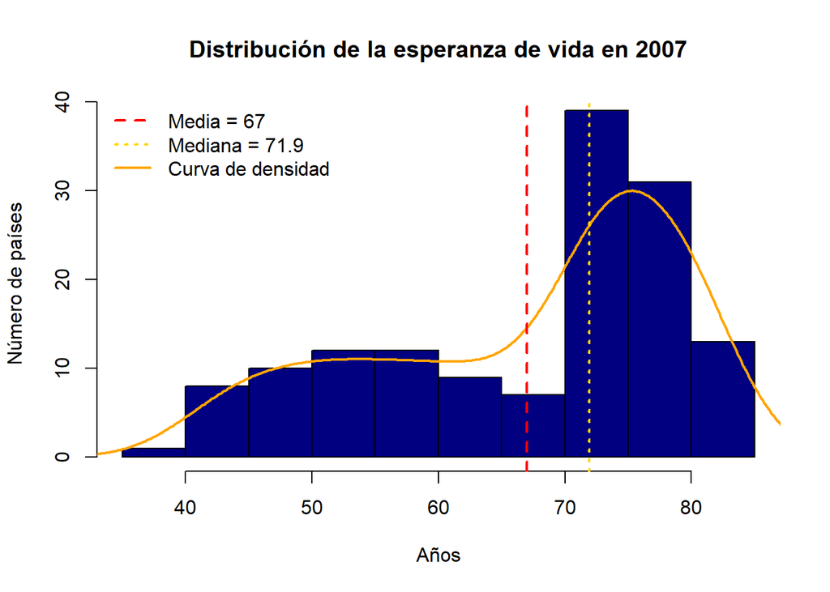

```r
# --- Histograma 1: Esperanza de vida ---
hist_vida <- hist(datos_2007$lifeExp,
                  col = "navyblue",
                  main = "Distribución de la esperanza de vida en 2007",
                  xlab = "Años",
                  ylab = "Número de países")

# Curva de densidad superpuesta. density() da una escala de PROBABILIDAD
# (el área bajo la curva suma 1), así que la reescalamos multiplicando
# por n (número de países) y por el ancho de cada barra del histograma,
# para que quede en la misma escala de conteo.
densidad_vida    <- density(datos_2007$lifeExp)
ancho_barra_vida <- diff(hist_vida$breaks)[1]
lines(densidad_vida$x,
      densidad_vida$y * length(datos_2007$lifeExp) * ancho_barra_vida,
      col = "orange", lwd = 2)

abline(v = media_vida,   col = "red",  lwd = 2, lty = 2)
abline(v = mediana_vida, col = "gold", lwd = 2, lty = 3)

legend("topleft",
       legend = c(paste0("Media = ", round(media_vida, 1)),
                  paste0("Mediana = ", round(mediana_vida, 1)),
                  "Curva de densidad"),
       col = c("red", "gold", "orange"),
       lty = c(2, 3, 1), lwd = 2, bty = "n")
```

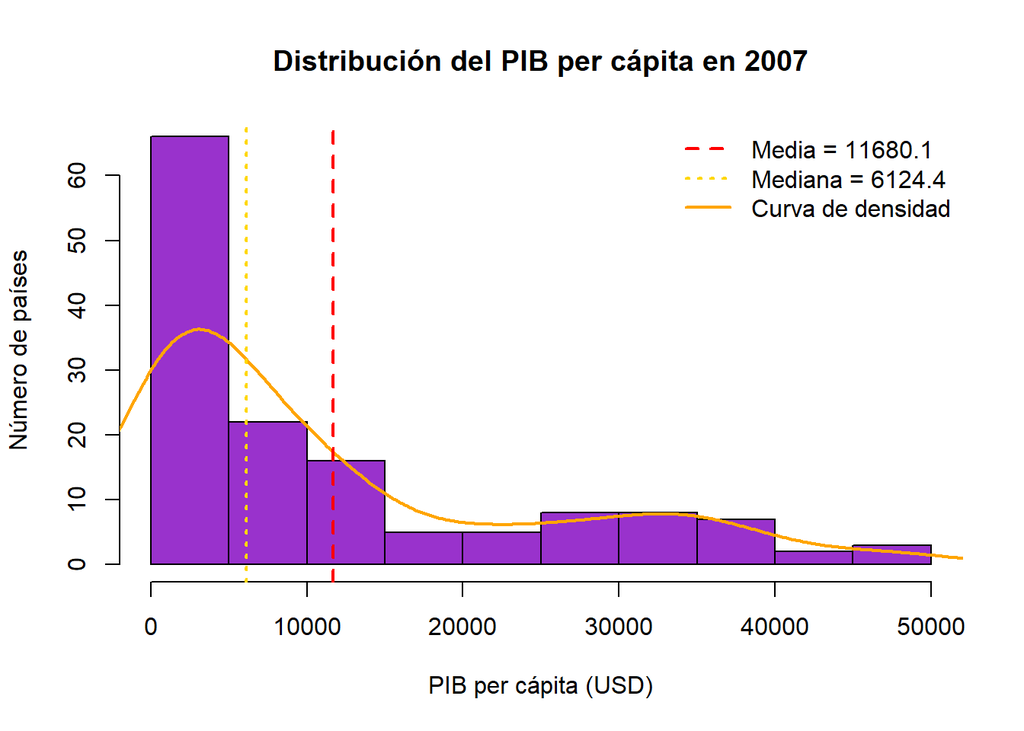

```r
# --- Histograma 2: PIB per cápita ---
media_pib   <- mean(datos_2007$gdpPercap)
mediana_pib <- median(datos_2007$gdpPercap)
rango_pib <- range(datos_2007$gdpPercap)

hist_pib <- hist(datos_2007$gdpPercap,
                 col = "darkorchid",
                 main = "Distribución del PIB per cápita en 2007",
                 xlab = "PIB per cápita (USD)",
                 ylab = "Número de países")

densidad_pib    <- density(datos_2007$gdpPercap)
ancho_barra_pib <- diff(hist_pib$breaks)[1]
lines(densidad_pib$x,
      densidad_pib$y * length(datos_2007$gdpPercap) * ancho_barra_pib,
      col = "orange", lwd = 2)

abline(v = media_pib,   col = "red",  lwd = 2, lty = 2)
abline(v = mediana_pib, col = "gold", lwd = 2, lty = 3)

legend("topright",
       legend = c(paste0("Media = ", round(media_pib, 1)),
                  paste0("Mediana = ", round(mediana_pib, 1)),
                  "Curva de densidad"),
       col = c("red", "gold", "orange"),
       lty = c(2, 3, 1), lwd = 2, bty = "n")
```

## 1.5 Parte 4 — Ejercicio 2: estadísticas y filtrado adicional (2007)

> *(Nota: la numeración salta de “Parte 2” a “Parte 4”, tal como estaba en el script original — la sección de tipos de objetos, arriba, cumple el rol de “Parte 3” aunque no llevaba ese número.)*

```r
## ---------------------------------------------------------
## Parte 4 — Ejercicio 2: estadísticas y filtrado adicional (2007)
## ---------------------------------------------------------
# Las medias y medianas ya se calcularon en la Parte 2 (media_vida,
# mediana_vida, media_pib, mediana_pib); aquí solo las imprimimos junto
# con el rango, y seguimos explorando el data.frame con más filtros.

rango_vida <- range(datos_2007$lifeExp)

cat("Esperanza de vida -> Media:", round(media_vida, 2),
    "| Mediana:", round(mediana_vida, 2), "\n")
```

```
## Esperanza de vida -> Media: 67.01 | Mediana: 71.94
```

```r
cat("PIB per cápita     -> Media:", round(media_pib, 2),
    "| Mediana:", round(mediana_pib, 2), "\n")
```

```
## PIB per cápita     -> Media: 11680.07 | Mediana: 6124.37
```

```r
americas_2007 <- datos_2007[datos_2007$continent == "Americas", ]
nrow(americas_2007)
```

```
## [1] 25
```

```r
indice_max <- which.max(datos_2007$gdpPercap)
datos_2007$country[indice_max]
```

```
## [1] Norway
## 142 Levels: Afghanistan Albania Algeria Angola Argentina Australia ... Zimbabwe
```

```r
datos_2007$gdpPercap[indice_max]
```

```
## [1] 49357.19
```

## 1.6 Parte 5 — Ejercicio 3a: for sobre un subconjunto de países de interés

```r
## ---------------------------------------------------------
## Parte 5 — Ejercicio 3a: for sobre un subconjunto de países de interés
## ---------------------------------------------------------
# Primer nivel del ejercicio: un loop sencillo sobre 9 países, con una
# clasificación binaria fija (umbral de 15,000 USD).

paises_interes <- c("Mexico", "United States", "Canada",
                    "Guatemala", "Costa Rica", "Germany", "Colombia", "Peru",
                    "Argentina")

sub_datos <- datos_2007[datos_2007$country %in% paises_interes, ]
sub_datos <- sub_datos[order(sub_datos$country), ]
sub_datos
```

```
## # A tibble: 9 × 6
##   country       continent  year lifeExp       pop gdpPercap
##   <fct>         <fct>     <int>   <dbl>     <int>     <dbl>
## 1 Argentina     Americas   2007    75.3  40301927    12779.
## 2 Canada        Americas   2007    80.7  33390141    36319.
## 3 Colombia      Americas   2007    72.9  44227550     7007.
## 4 Costa Rica    Americas   2007    78.8   4133884     9645.
## 5 Germany       Europe     2007    79.4  82400996    32170.
## 6 Guatemala     Americas   2007    70.3  12572928     5186.
## 7 Mexico        Americas   2007    76.2 108700891    11978.
## 8 Peru          Americas   2007    71.4  28674757     7409.
## 9 United States Americas   2007    78.2 301139947    42952.
```

```r
for (i in 1:nrow(sub_datos)) {
  pais <- as.character(sub_datos$country[i])
  pib  <- sub_datos$gdpPercap[i]

  nivel <- if (pib >= 15000) "ALTO INGRESO" else "INGRESO MEDIO/BAJO"

  cat(pais, "-> PIB per cápita:", round(pib, 1), "|", nivel, "\n")
}
```

```
## Argentina -> PIB per cápita: 12779.4 | INGRESO MEDIO/BAJO
## Canada -> PIB per cápita: 36319.2 | ALTO INGRESO
## Colombia -> PIB per cápita: 7006.6 | INGRESO MEDIO/BAJO
## Costa Rica -> PIB per cápita: 9645.1 | INGRESO MEDIO/BAJO
## Germany -> PIB per cápita: 32170.4 | ALTO INGRESO
## Guatemala -> PIB per cápita: 5186.1 | INGRESO MEDIO/BAJO
## Mexico -> PIB per cápita: 11977.6 | INGRESO MEDIO/BAJO
## Peru -> PIB per cápita: 7408.9 | INGRESO MEDIO/BAJO
## United States -> PIB per cápita: 42951.7 | ALTO INGRESO
```

## 1.7 Parte 6 — Ejercicio 3b: for sobre TODOS los países (extiende 5)

```r
## ---------------------------------------------------------
## Parte 6 — Ejercicio 3b: for sobre TODOS los países (extiende 5)
## ---------------------------------------------------------
# Segundo nivel del ejercicio: en vez de un subconjunto fijo y un umbral
# arbitrario, recorremos los 142 países y comparamos cada uno contra la
# media real (media_pib), además de marcar los casos extremos.

todos_datos <- datos_2007[order(datos_2007$country), ]

pib_max <- max(datos_2007$gdpPercap)
pib_min <- min(datos_2007$gdpPercap)

cat("====== PIB per cápita 2007 — todos los países ======\n")
```

```
## ====== PIB per cápita 2007 — todos los países ======
```

```r
cat("Máximo :", round(pib_max, 1), "\n")
```

```
## Máximo : 49357.2
```

```r
cat("Mínimo :", round(pib_min, 1), "\n")
```

```
## Mínimo : 277.6
```

```r
cat("Media  :", round(media_pib, 1), "\n")
```

```
## Media  : 11680.1
```

```r
cat("Mediana:", round(mediana_pib, 1), "\n\n")
```

```
## Mediana: 6124.4
```

```r
for (i in 1:nrow(todos_datos)) {
  pais <- as.character(todos_datos$country[i])
  pib  <- todos_datos$gdpPercap[i]

  nivel <- if (pib >= media_pib) "SOBRE LA MEDIA" else "BAJO LA MEDIA"

  etiqueta <- ""
  if (pib == pib_max) etiqueta <- " <-- PIB MÁXIMO"
  if (pib == pib_min) etiqueta <- " <-- PIB MÍNIMO"

  cat(pais, "-> PIB per cápita:", round(pib, 1), "|", nivel, etiqueta, "\n")
}
```

```
## Afghanistan -> PIB per cápita: 974.6 | BAJO LA MEDIA
## Albania -> PIB per cápita: 5937 | BAJO LA MEDIA
## Algeria -> PIB per cápita: 6223.4 | BAJO LA MEDIA
## Angola -> PIB per cápita: 4797.2 | BAJO LA MEDIA
## Argentina -> PIB per cápita: 12779.4 | SOBRE LA MEDIA
## Australia -> PIB per cápita: 34435.4 | SOBRE LA MEDIA
## Austria -> PIB per cápita: 36126.5 | SOBRE LA MEDIA
## Bahrain -> PIB per cápita: 29796 | SOBRE LA MEDIA
## Bangladesh -> PIB per cápita: 1391.3 | BAJO LA MEDIA
## Belgium -> PIB per cápita: 33692.6 | SOBRE LA MEDIA
## Benin -> PIB per cápita: 1441.3 | BAJO LA MEDIA
## Bolivia -> PIB per cápita: 3822.1 | BAJO LA MEDIA
## Bosnia and Herzegovina -> PIB per cápita: 7446.3 | BAJO LA MEDIA
## Botswana -> PIB per cápita: 12569.9 | SOBRE LA MEDIA
## Brazil -> PIB per cápita: 9065.8 | BAJO LA MEDIA
## Bulgaria -> PIB per cápita: 10680.8 | BAJO LA MEDIA
## Burkina Faso -> PIB per cápita: 1217 | BAJO LA MEDIA
## Burundi -> PIB per cápita: 430.1 | BAJO LA MEDIA
## Cambodia -> PIB per cápita: 1713.8 | BAJO LA MEDIA
## Cameroon -> PIB per cápita: 2042.1 | BAJO LA MEDIA
## Canada -> PIB per cápita: 36319.2 | SOBRE LA MEDIA
## Central African Republic -> PIB per cápita: 706 | BAJO LA MEDIA
## Chad -> PIB per cápita: 1704.1 | BAJO LA MEDIA
## Chile -> PIB per cápita: 13171.6 | SOBRE LA MEDIA
## China -> PIB per cápita: 4959.1 | BAJO LA MEDIA
## Colombia -> PIB per cápita: 7006.6 | BAJO LA MEDIA
## Comoros -> PIB per cápita: 986.1 | BAJO LA MEDIA
## Congo, Dem. Rep. -> PIB per cápita: 277.6 | BAJO LA MEDIA  <-- PIB MÍNIMO
## Congo, Rep. -> PIB per cápita: 3632.6 | BAJO LA MEDIA
## Costa Rica -> PIB per cápita: 9645.1 | BAJO LA MEDIA
## Cote d'Ivoire -> PIB per cápita: 1544.8 | BAJO LA MEDIA
## Croatia -> PIB per cápita: 14619.2 | SOBRE LA MEDIA
## Cuba -> PIB per cápita: 8948.1 | BAJO LA MEDIA
## Czech Republic -> PIB per cápita: 22833.3 | SOBRE LA MEDIA
## Denmark -> PIB per cápita: 35278.4 | SOBRE LA MEDIA
## Djibouti -> PIB per cápita: 2082.5 | BAJO LA MEDIA
## Dominican Republic -> PIB per cápita: 6025.4 | BAJO LA MEDIA
## Ecuador -> PIB per cápita: 6873.3 | BAJO LA MEDIA
## Egypt -> PIB per cápita: 5581.2 | BAJO LA MEDIA
## El Salvador -> PIB per cápita: 5728.4 | BAJO LA MEDIA
```

[output cut: 87 more lines]

```
## Thailand -> PIB per cápita: 7458.4 | BAJO LA MEDIA
## Togo -> PIB per cápita: 883 | BAJO LA MEDIA
## Trinidad and Tobago -> PIB per cápita: 18008.5 | SOBRE LA MEDIA
## Tunisia -> PIB per cápita: 7092.9 | BAJO LA MEDIA
## Turkey -> PIB per cápita: 8458.3 | BAJO LA MEDIA
## Uganda -> PIB per cápita: 1056.4 | BAJO LA MEDIA
## United Kingdom -> PIB per cápita: 33203.3 | SOBRE LA MEDIA
## United States -> PIB per cápita: 42951.7 | SOBRE LA MEDIA
## Uruguay -> PIB per cápita: 10611.5 | BAJO LA MEDIA
## Venezuela -> PIB per cápita: 11415.8 | BAJO LA MEDIA
## Vietnam -> PIB per cápita: 2441.6 | BAJO LA MEDIA
## West Bank and Gaza -> PIB per cápita: 3025.3 | BAJO LA MEDIA
## Yemen, Rep. -> PIB per cápita: 2280.8 | BAJO LA MEDIA
## Zambia -> PIB per cápita: 1271.2 | BAJO LA MEDIA
## Zimbabwe -> PIB per cápita: 469.7 | BAJO LA MEDIA
```

## 1.8 Parte 7 — Reporte por continente

```r
## ---------------------------------------------------------
## Parte 7 — Reporte por continente
## ---------------------------------------------------------

# --- Paso 1: Estadísticas por continente ---
continentes_unicos <- levels(gapminder$continent)
continentes_unicos
```

```
## [1] "Africa"   "Americas" "Asia"     "Europe"   "Oceania"
```

```r
cat("====== Reporte por continente (2007) ======\n")
```

```
## ====== Reporte por continente (2007) ======
```

```r
for (cont in continentes_unicos) {
  sub <- datos_2007[datos_2007$continent == cont, ]

  pib_prom  <- mean(sub$gdpPercap)
  vida_prom <- mean(sub$lifeExp)
  n_paises  <- nrow(sub)

  cat(cont, "| Países:", n_paises,
      "| PIB per cápita promedio:", round(pib_prom, 1),
      "| Esperanza de vida promedio:", round(vida_prom, 1), "\n")
}
```

```
## Africa | Países: 52 | PIB per cápita promedio: 3089 | Esperanza de vida promedio: 54.8
## Americas | Países: 25 | PIB per cápita promedio: 11003 | Esperanza de vida promedio: 73.6
## Asia | Países: 33 | PIB per cápita promedio: 12473 | Esperanza de vida promedio: 70.7
## Europe | Países: 30 | PIB per cápita promedio: 25054.5 | Esperanza de vida promedio: 77.6
## Oceania | Países: 2 | PIB per cápita promedio: 29810.2 | Esperanza de vida promedio: 80.7
```

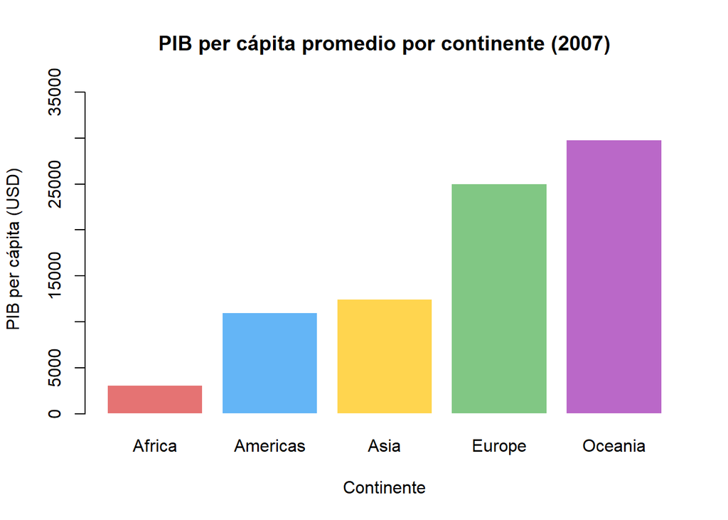

```r
# --- Paso 2: Gráfica — PIB per cápita promedio por continente ---
prom_por_continente <- tapply(datos_2007$gdpPercap,
                              datos_2007$continent, mean)

barplot(prom_por_continente,
        col    = c("#E57373", "#64B5F6", "#FFD54F", "#81C784", "#BA68C8"),
        border = "white",
        main   = "PIB per cápita promedio por continente (2007)",
        xlab   = "Continente",
        ylab   = "PIB per cápita (USD)",
        ylim   = c(0, max(prom_por_continente) * 1.2))
```

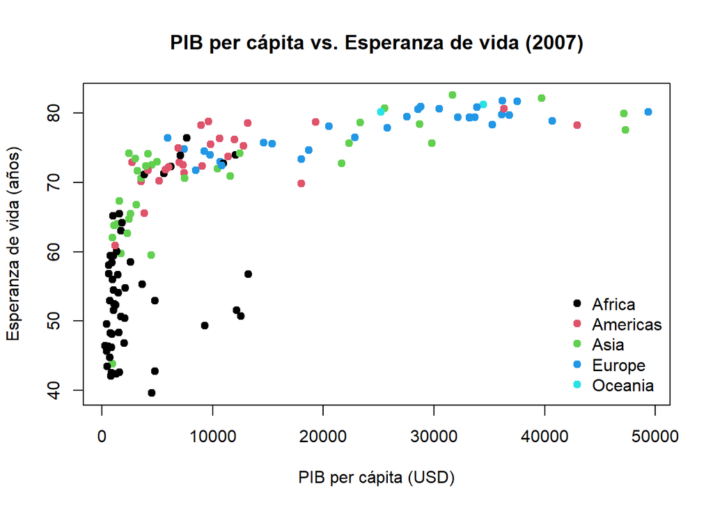

```r
# --- Paso 3: Relación PIB vs. esperanza de vida ---
plot(datos_2007$gdpPercap, datos_2007$lifeExp,
     col = as.numeric(datos_2007$continent), pch = 19,
     main = "PIB per cápita vs. Esperanza de vida (2007)",
     xlab = "PIB per cápita (USD)", ylab = "Esperanza de vida (años)")

legend("bottomright", legend = levels(datos_2007$continent),
       col = 1:5, pch = 19, bty = "n")
```